# Pilot 2 Analysis: Sepsis onset by Sepsis-3 criteria diverges from clinical judgement of timing of antibiotic initiation

Gary Weissman

## Introduction

This analysis is based on a handful of respones to a pilot version of the survey with 8 clinical vignettes that was distributed to members of the CRWIP group on May 11, 2020. The link to this version of the pilot survey is here: https://upenn.co1.qualtrics.com/jfe/form/SV_4OaetN2lwRVyB3T

## Analysis

```r
library(data.table)
library(ggplot2)
library(ggsci)
library(lme4)
rr <- fread('Sepsis+Annotations+Pilot+-+v2_May+12%2C+2020_07.23.csv')
cw <- fread('crosswalk_sepsis.csv')
cw <- cw[, .(onset_hrs = hosp_adm_to_sepsis_onset_hrs,
             antbx_delay_cat, antbx_delay_hrs, window_lower)][, vignette_id := factor(1:8)]
```

### Who responded?

The listed specialtise of those responding were:

```r
knitr::kable(table(rr$Q3))
```

| Var1 | Freq |
| --- | --- |
| cr care | 1 |
| Medical Critical Care | 1 |
| pulmonary | 1 |
| Pulmonary and critical care | 2 |
| Pulmonary and Critical Care Medicine | 2 |
| Pulmonary critical care medicine | 1 |

When did you graduate medical school?

```r
knitr::kable(table(rr$Q2, useNA = 'always'))
```

| Var1 | Freq |
| --- | --- |
| 1996 | 1 |
| 2001 | 1 |
| 2003 | 1 |
| 2012 | 1 |
| 2014 | 1 |
| 2015 | 2 |
| 2016 | 1 |
| NA | 0 |

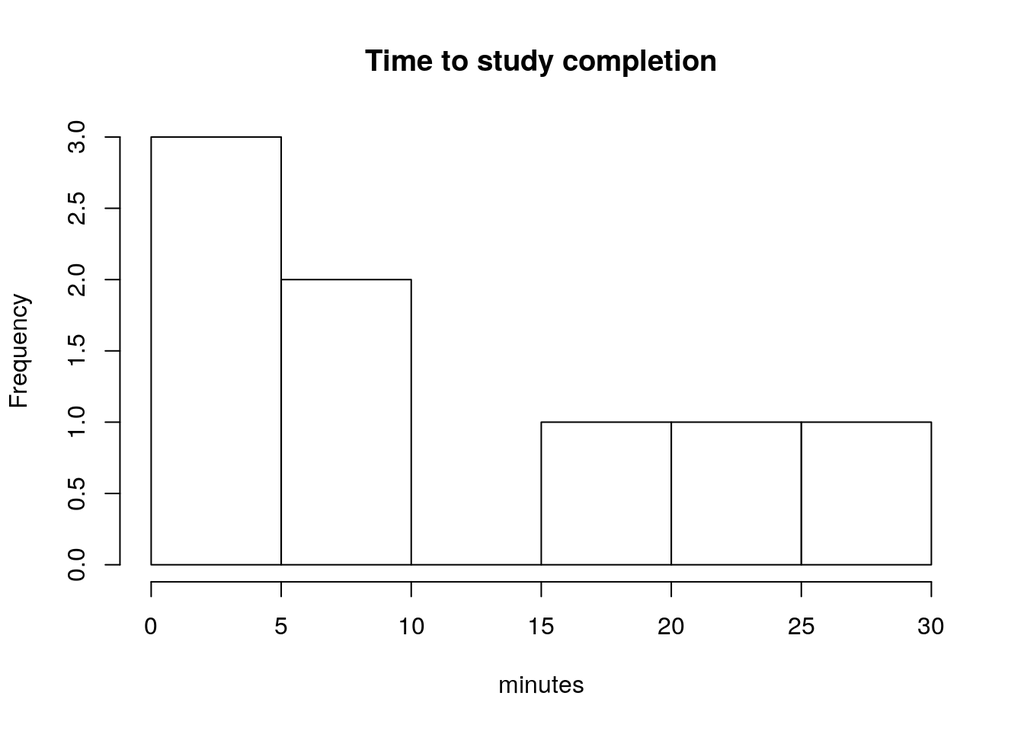

```r
hist(rr$`Duration (in seconds)` / 60,
     main = 'Time to study completion',
     xlab = 'minutes')
```

### Categorical responses

First look at the categorical responses to each question. The options for each question was a multiple choice of:

1. “I would have started antibiotics at: XXX”
2. “There is insufficient data to determine when antibiotics should have been started.”
3. “I would not have started antibiotics for this patient during the time window.”

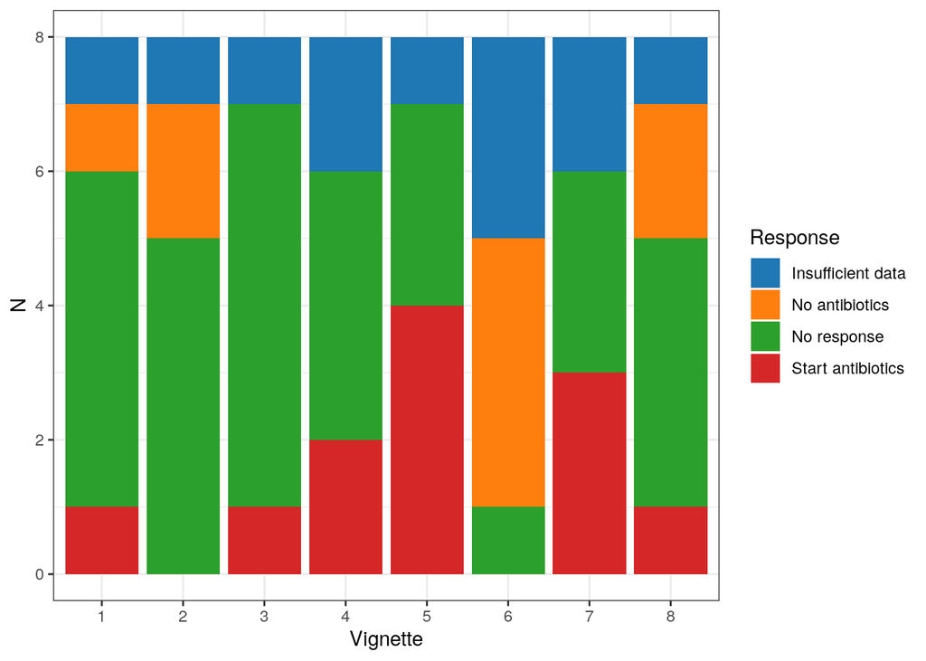

```r
res_cat_1 <- rr[! is.na(Q2), paste0('Q',c(5:11,13))][, participant_id := .I]
res_cat_2 <- melt(res_cat_1, id.vars = c('participant_id'))
res_cat_2[, vignette_id := factor(variable, labels = 1:8)]
# Clean up responses and shorten for plotting
res_cat_2[value == '', value_clean := 'No response']
res_cat_2[value == 'I would have started broad-spectrum antibiotics at hour:',
          value_clean := 'Start antibiotics']
res_cat_2[value == 'I would not have started antibiotics for this patient during the time window.',
          value_clean := 'No antibiotics']
res_cat_2[value == 'There is insufficient data to determine when antibiotics should have been started.',
          value_clean := 'Insufficient data']
res_cat_3 <- res_cat_2[, .N, by = .(vignette_id, value_clean)]

# Now plot
ggplot(res_cat_3, aes(vignette_id, y = N,
                      fill = value_clean, group = value_clean)) +
  geom_bar(stat = 'identity') +
  theme_bw() +
  scale_fill_d3(name = 'Response') +
  scale_x_discrete('Vignette')
```

### Continuous responses

For those users who selected to start antibiotics, they were prompted to enter a start time for antibiotics. Here we display the start time relative to the onset of sepsis as defined by Sepsis-3. Thus negative values indicate starting antibiotics earlier and positive values indicate starting antibiotics later.

```r
res_cont_1 <- rr[! is.na(Q2), paste0('Q',c(5:11,13),'_4_TEXT')][,participant_id := .I]
res_cont_2 <- melt(res_cont_1, id.vars = c('participant_id'))
```

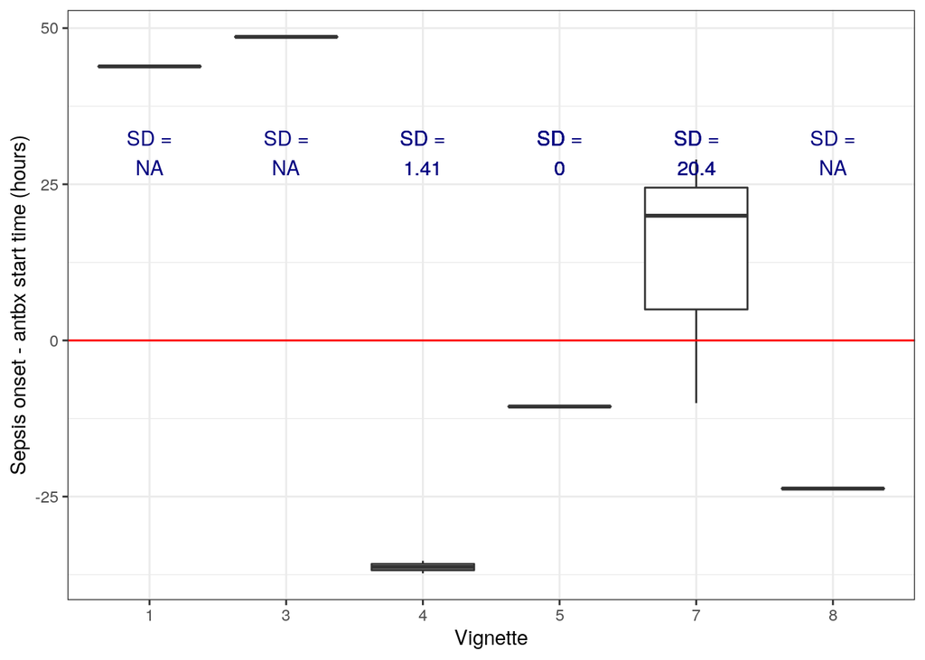

```r
res_cont_2[, vignette_id := factor(variable, labels = 1:8)]
res_cont_2 <- res_cont_2[! is.na(value)]
res_cont_3 <- merge(res_cont_2, cw, by = 'vignette_id', all.x = TRUE)
res_cont_3[, diff_hrs := value - onset_hrs + window_lower - 1]
res_cont_3[, sd := format(sd(diff_hrs), digits = 3), by = vignette_id]

# Now plot
ggplot(res_cont_3, aes(vignette_id, diff_hrs)) +
  geom_boxplot() +
  geom_text(aes(label = paste0('SD =\n',sd)), y = 30, color = 'navy') +
  geom_hline(yintercept = 0, color = 'red') +
  theme_bw() +
  scale_x_discrete('Vignette') +
  scale_y_continuous('Sepsis onset - antbx start time (hours)')
```

The vignettes themselves were selected by the degree of delay in their antibiotic administration, with 2 vignettes from each category of degree of delay. This was done because there may be differences in severity of illness, clinical recognition, or other factors that contribute to these differences in care processes. Now let’s look at the results by degree of delay.

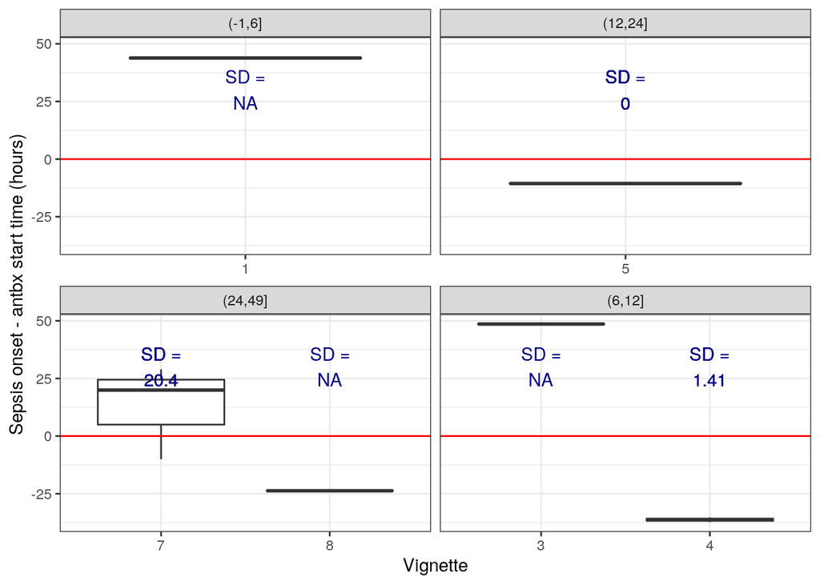

```r
ggplot(res_cont_3, aes(vignette_id, diff_hrs)) +
  geom_boxplot() +
  geom_text(aes(label = paste0('SD =\n',sd)), y = 30, color = 'navy') +
  geom_hline(yintercept = 0, color = 'red') +
  theme_bw() +
  scale_x_discrete('Vignette') +
  scale_y_continuous('Sepsis onset - antbx start time (hours)') +
  facet_wrap(~antbx_delay_cat, scale = 'free_x')
```

What proportion of annotations *preceded* the Sepsis-3 onset time?

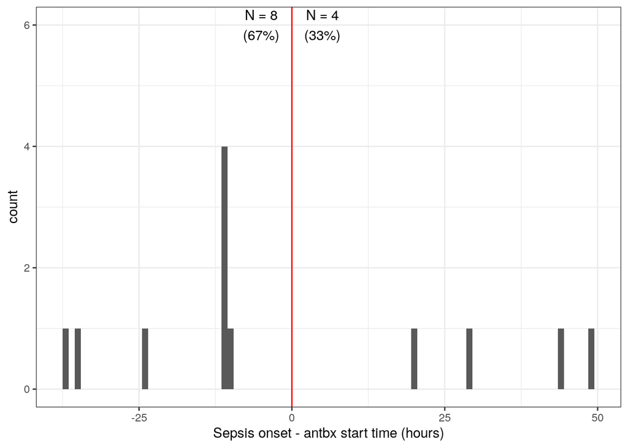

```r
ggplot(res_cont_3, aes(diff_hrs)) +
  geom_histogram(binwidth = 1) +
  geom_vline(xintercept = 0, color = 'red') +
  theme_bw() +
  scale_x_continuous('Sepsis onset - antbx start time (hours)') +
  annotate('text', x = -5, y = 6, label = paste0('N = ', sum(res_cont_3$diff_hrs < 0),
                                                 '\n(', format(mean(res_cont_3$diff_hrs < 0) * 100, digits = 2), '%)')) +
  annotate('text', x = 5, y = 6, label = paste0('N = ', sum(res_cont_3$diff_hrs >= 0),
                                                 '\n(', format(mean(res_cont_3$diff_hrs >= 0) * 100, digits = 2), '%)'))
```

### Sample analysis

The proposed analysis is as follows:

```r
# Fit model
m1 <- lmer(diff_hrs ~ (1 | participant_id) + (1 | vignette_id),
           data = res_cont_3)
summary(m1)
```

```
## Linear mixed model fit by REML ['lmerMod']
## Formula: diff_hrs ~ (1 | participant_id) + (1 | vignette_id)
##    Data: res_cont_3
##
## REML criterion at convergence: 99.4
##
## Scaled residuals:
##      Min       1Q   Median       3Q      Max
## -0.63036 -0.34438  0.04741  0.13112  0.98255
##
## Random effects:
##  Groups         Name        Variance Std.Dev.
##  vignette_id    (Intercept) 1240.99  35.228
##  participant_id (Intercept)  218.99  14.798
##  Residual                     11.66   3.414
## Number of obs: 12, groups:  vignette_id, 6; participant_id, 5
##
## Fixed effects:
##             Estimate Std. Error t value
## (Intercept)    1.006     15.897   0.063
```

```r
# Is the intercept truly different than zero?
# Force a Zero interecept
m2 <- lmer(diff_hrs ~ 0 + (1 | participant_id) + (1 | vignette_id),
           data = res_cont_3)
summary(m2)
```

```
## Linear mixed model fit by maximum likelihood  ['lmerMod']
## Formula: diff_hrs ~ 0 + (1 | participant_id) + (1 | vignette_id)
##    Data: res_cont_3
##
##      AIC      BIC   logLik deviance df.resid
##    112.7    114.2    -53.4    106.7        9
##
## Scaled residuals:
##      Min       1Q   Median       3Q      Max
## -0.63414 -0.35822  0.04623  0.14508  0.98899
##
## Random effects:
##  Groups         Name        Variance Std.Dev.
##  vignette_id    (Intercept) 1066.34  32.655
##  participant_id (Intercept)  207.76  14.414
##  Residual                     11.76   3.429
## Number of obs: 12, groups:  vignette_id, 6; participant_id, 5
```

```r
# Are these models different?
anova(m1, m2, test = 'LRT')
```

```
## refitting model(s) with ML (instead of REML)
```

```
## Data: res_cont_3
## Models:
## m2: diff_hrs ~ 0 + (1 | participant_id) + (1 | vignette_id)
## m1: diff_hrs ~ (1 | participant_id) + (1 | vignette_id)
##    npar    AIC    BIC  logLik deviance  Chisq Df Pr(>Chisq)
## m2    3 112.73 114.19 -53.368   106.73
## m1    4 114.73 116.67 -53.365   106.73 0.0047  1     0.9456
```

```r
# Now also repeat analysis adjusting for patient specialty and center when we have more data...
```

## Instrument feedback

- consider include only vignetttes with complete data (e.g. at least one WBC value, etc)
- change language to, “If you had been caring for the patient, when would have been reasonable to iniitiate broad-spectrum antibiotics…” and be sure to clarify we are *not* asking a “what could have been done differently” kind of question
- shrink the size of the plot a little bit and consider putting x-axis on all panels
- consider 6 vs 8 vignettes
- participant feels “strain” if the sepsis diagnosis isn’t obvious, though important to keep these cases because they are more informative
- more cinical info (e.g. on immune suppression) would be helpful, have enough lab values
- definitely important to include 1-2 *not* sepsis cases
- split each vignette into 2-part question, 1) sepsis yes/no vs insufficient information, 2) when start antbx?